# Problems set 4

## Price vs. x

```r
library(ggplot2)
library(ggthemes)
theme_set(theme_minimal())
library(dplyr)
data(diamonds)

summary(diamonds$x)
```

```
##    Min. 1st Qu.  Median    Mean 3rd Qu.    Max.
##   0.000   4.710   5.700   5.731   6.540  10.740
```

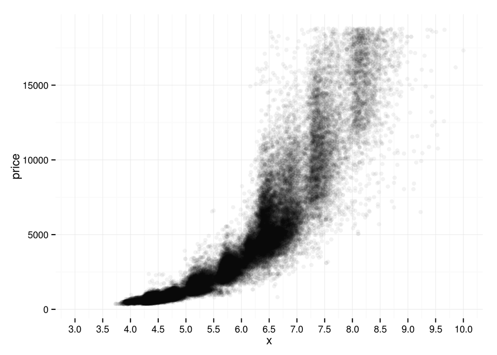

```r
ggplot(aes(x=x, y=price), data=diamonds) +
  geom_point(alpha = 0.05) +
  scale_x_continuous(limits=c(3,10), breaks=seq(3,10,0.5))
```

Observations:

- price seems to grow exponentially wit the lenght (x) value
- there seems to exist ‘size clusters’: e.g. for value of ~5.25 there is significantly more observations than for 5.0 and 5.5; same for larges sizes (e.g. 5.75)
- there is less large diamonds (size > 7) than small and medium ones
- one can’t buy small diamonds for more than 5000$
- buying large diamond for < 5000$ is almost impossible

```r
# correlation between price and x (0.88)
cor.test(diamonds$price, diamonds$x)
```

```
##
##  Pearson's product-moment correlation
##
## data:  diamonds$price and diamonds$x
## t = 440.16, df = 53938, p-value < 2.2e-16
## alternative hypothesis: true correlation is not equal to 0
## 95 percent confidence interval:
##  0.8825835 0.8862594
## sample estimates:
##       cor
## 0.8844352
```

```r
# correlation between price and y (0.87)
cor.test(diamonds$price, diamonds$y)
```

```
##
##  Pearson's product-moment correlation
##
## data:  diamonds$price and diamonds$y
## t = 401.14, df = 53938, p-value < 2.2e-16
## alternative hypothesis: true correlation is not equal to 0
## 95 percent confidence interval:
##  0.8632867 0.8675241
## sample estimates:
##       cor
## 0.8654209
```

```r
# correlation between price and z (0.86)
cor.test(diamonds$price, diamonds$z)
```

```
##
##  Pearson's product-moment correlation
##
## data:  diamonds$price and diamonds$z
## t = 393.6, df = 53938, p-value < 2.2e-16
## alternative hypothesis: true correlation is not equal to 0
## 95 percent confidence interval:
##  0.8590541 0.8634131
## sample estimates:
##       cor
## 0.8612494
```

## Price vs. depth

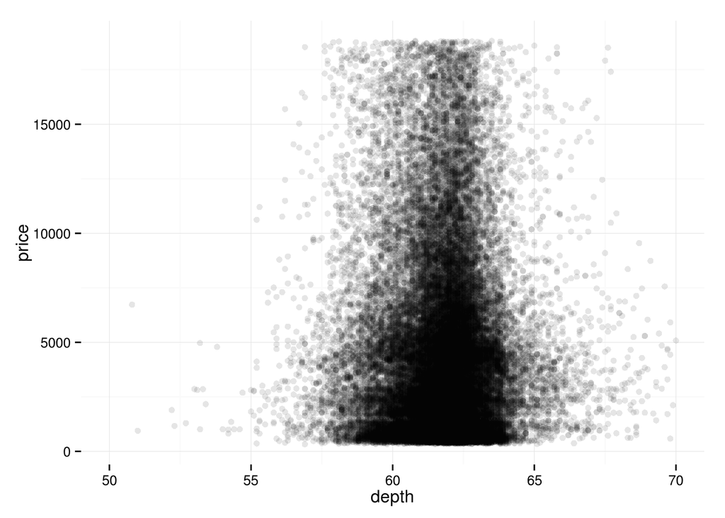

```r
ggplot(aes(x = depth, y = price), data = diamonds) +
  geom_point(alpha = 0.1) +
  scale_x_continuous(limits=c(50, 70))
```

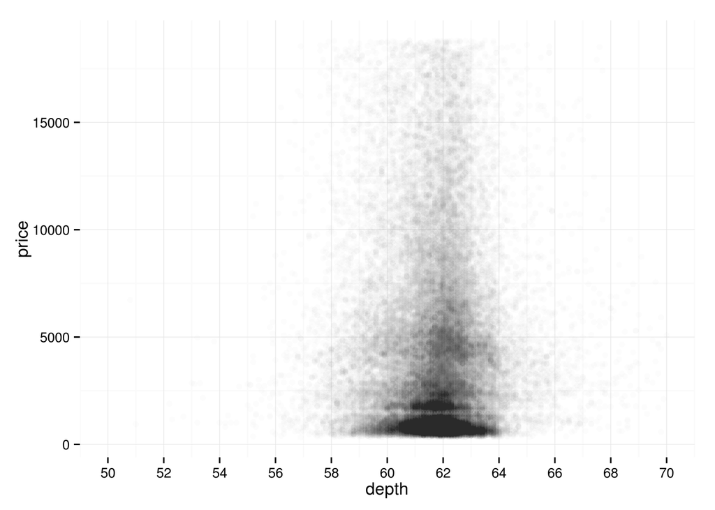

```r
# Change the code to make the transparency of the
# points to be 1/100 of what they are now and mark
# the x-axis every 2 units.
ggplot(aes(x = depth, y = price), data = diamonds) +
  geom_point(alpha = 0.01) +
  scale_x_continuous(limits=c(50, 70), breaks=seq(50, 70, 2))
```

Typical depth range: 58 to 64.

```r
# What's the correlation of depth vs price? (-0.01)
cor.test(diamonds$depth, diamonds$price)
```

```
##
##  Pearson's product-moment correlation
##
## data:  diamonds$depth and diamonds$price
## t = -2.473, df = 53938, p-value = 0.0134
## alternative hypothesis: true correlation is not equal to 0
## 95 percent confidence interval:
##  -0.019084756 -0.002208537
## sample estimates:
##        cor
## -0.0106474
```

Would you use depth to predict price of a diamond: No Why: low absolute value of correlation coefficient (next to 0) means there is no correlation between depth and price. Diamonds of any depth can achieve both very low and very high price.

## Price vs. carat

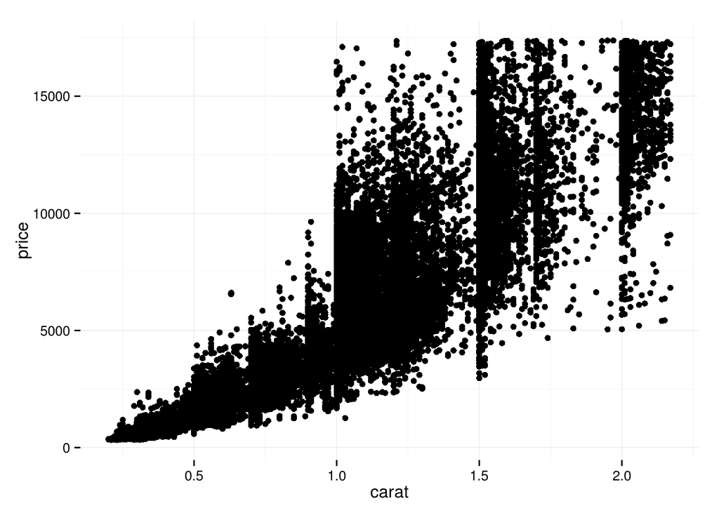

```r
diamonds.top1p_excluded = subset(diamonds,
                                 diamonds$carat < quantile(diamonds$carat, .99) & diamonds$price < quantile(diamonds$price, .99))
ggplot(aes(x = carat, y = price), data = diamonds.top1p_excluded) +
  geom_point()
```

## Price vs. volume

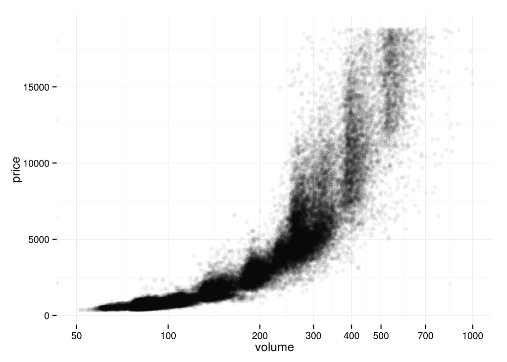

```r
diamonds$volume = diamonds$x * diamonds$y * diamonds$x
ggplot(aes(x = volume, y = price), data = diamonds) +
  geom_point(alpha = 0.05) +
  scale_x_log10(limits=c(50, 1000), breaks=c(50, 100, 200, 300, 400, 500, 700, 1000))
```

Observations:

- price vs volume follows similar trend as price vs x (exponential growth of price with x)
- there are volume clusters (e.g. 150, 200, 400, 500)
- diamonds with volume < 350 are most popular
- log scale is not required here - continuous scale works better (easier to interpret)

Did not notice:

- outliers:
  - expensive diamond near 4000 and a cheaper diamond with a volume near 900 (I removed the outliers to make the chart x-axis limits better)
- diamonds with volume == 0 (8!)

```r
# What's the correlation of price and volume? (0.92)
# NOTE: instructor notes suggest removing outliers (vol > 800 && vol = 0)
cor.test(diamonds$price, diamonds$volume)
```

```
##
##  Pearson's product-moment correlation
##
## data:  diamonds$price and diamonds$volume
## t = 530.85, df = 53938, p-value < 2.2e-16
## alternative hypothesis: true correlation is not equal to 0
## 95 percent confidence interval:
##  0.9147907 0.9175024
## sample estimates:
##      cor
## 0.916157
```

### Adjustments - price vs. volume

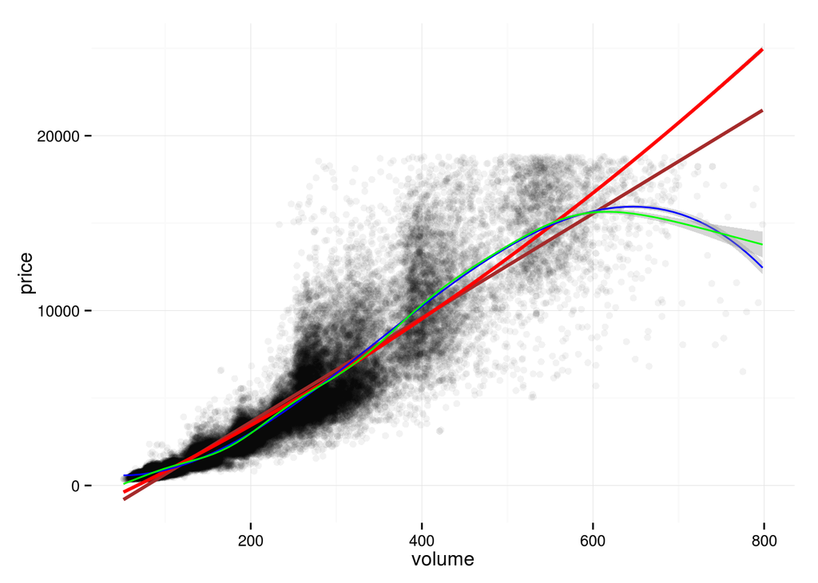

```r
# Subset the data to exclude diamonds with a volume
# greater than or equal to 800. Also, exclude diamonds
# with a volume of 0. Adjust the transparency of the
# points and add a linear model to the plot. (See the
# Instructor Notes or look up the documentation of
# geom_smooth() for more details about smoothers.)
require(mgcv)
diamonds.vol_nooutliers = diamonds[diamonds$volume < 800 & diamonds$volume != 0, ]
ggplot(aes(x = volume, y = price), data = diamonds.vol_nooutliers) +
  geom_point(alpha = 0.05) +
  stat_smooth(method = 'lm', formula = y ~ x, color = 'brown', size = 1) +
  stat_smooth(method = 'lm', formula = y ~ poly(x, 2), color = 'red', size = 1) +
  stat_smooth(method = 'lm', formula = y ~ poly(x, 3), color = 'blue') +
  stat_smooth(method = 'gam', formula = y ~ s(x), color = 'green')
```

Observations:

- linear and square models are worse than cubic and gam models - they overprice smaller diamonds
- estimating value of diamonds with volume > 300 is not doable with any models - variance is too high and model cannot determine the price based on volume only

## Mean price by clarity

Use the function dplyr package to create a new data frame containing info on diamonds by clarity.

Name the data frame diamondsByClarity

The data frame should contain the following variables in this order.

```
1. mean_price
2. median_price
3. min_price
4. max_price
5. n
```

```r
diamondsByClarity = group_by(diamonds, clarity)
diamondsByClarity = summarise(diamondsByClarity,
                              mean_price = mean(price),
                              median_price = median(price),
                              min_price = min(price),
                              max_price = max(price),
                              n = n())
head(diamondsByClarity)
```

```
## Source: local data frame [6 x 6]
##
##   clarity mean_price median_price min_price max_price     n
##    (fctr)      (dbl)        (dbl)     (int)     (int) (int)
## 1      I1   3924.169         3344       345     18531   741
## 2     SI2   5063.029         4072       326     18804  9194
## 3     SI1   3996.001         2822       326     18818 13065
## 4     VS2   3924.989         2054       334     18823 12258
## 5     VS1   3839.455         2005       327     18795  8171
## 6    VVS2   3283.737         1311       336     18768  5066
```

## Bar Charts of Mean Price

We’ve created summary data frames with the mean price by clarity and color. You can run the code in R to verify what data is in the variables diamonds_mp_by_clarity and diamonds_mp_by_color.

Your task is to write additional code to create two bar plots on one output image using the grid.arrange() function from the package gridExtra.

flowigdata.com article on Bar Charts vs Histograms: http://flowingdata.com/2014/02/27/how-to-read-histograms-and-use-them-in-r/

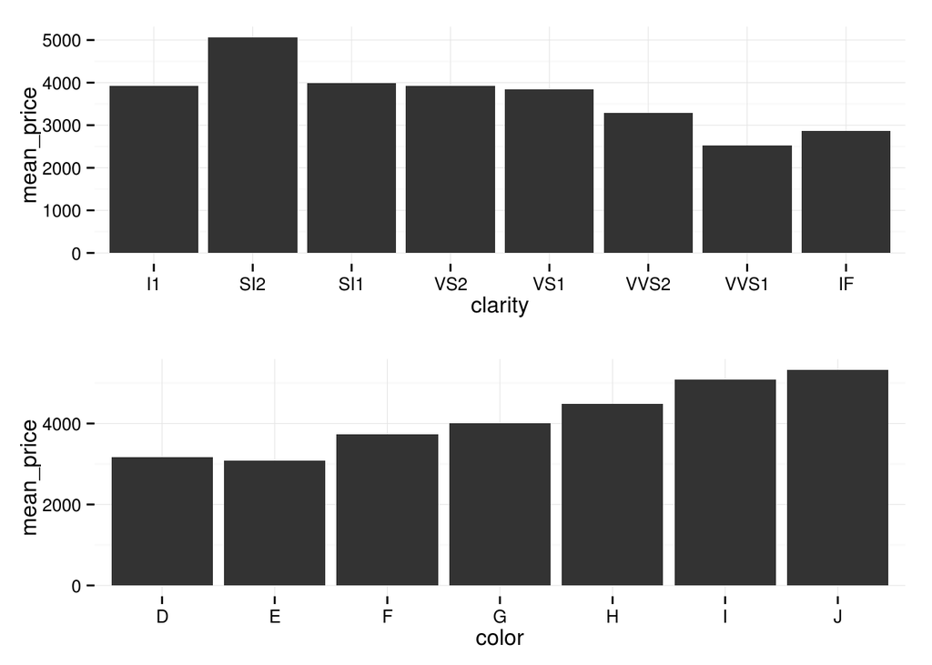

```r
data(diamonds)
library(dplyr)
library(gridExtra)

diamonds_by_clarity <- group_by(diamonds, clarity)
diamonds_mp_by_clarity <- summarise(diamonds_by_clarity, mean_price = mean(price))

diamonds_by_color <- group_by(diamonds, color)
diamonds_mp_by_color <- summarise(diamonds_by_color, mean_price = mean(price))

#diamonds_by_cut <- group_by(diamonds, cut)
#diamonds_mp_by_cut <- summarise(diamonds_by_cut, mean_price = mean(price))

p1 <- ggplot(aes(x = clarity, y = mean_price), data = diamonds_mp_by_clarity) + geom_bar(stat='identity')
p2 <- ggplot(aes(x = color, y = mean_price), data = diamonds_mp_by_color) + geom_bar(stat='identity')
#p3 <- ggplot(aes(x = cut, y = mean_price), data = diamonds_mp_by_cut) + geom_bar(stat='identity')
grid.arrange(p1, p2, ncol = 1)
```

## Gapminder Revisited

```r
library(openxlsx)
library(tidyr)
fertility <- read.xlsx('indicator undata total_fertility.xlsx', rowNames = TRUE, rows=1:259)
fertility <- mutate(fertility, country=rownames(fertility))
fertility <- gather(fertility, year, "fertility", 1:(length(fertility)-1), convert=TRUE)
fertility <- arrange(fertility, country, year)

income <- read.xlsx('indicator gapminder gdp_per_capita_ppp.xlsx', rowNames = TRUE, rows=1:260)
income <- mutate(income, country=rownames(income))
income <- gather(income, year, "fertility", 1:(length(income)-1), convert = TRUE)
income <- arrange(income, country, year)

fer_inc <- inner_join(income, fertility, by = c("country", "year"))
names(fer_inc) <- c("country", "year", "income", "fertility")
head(fer_inc)
```

```
##    country year income fertility
## 1 Abkhazia 1800     NA        NA
## 2 Abkhazia 1801     NA        NA
## 3 Abkhazia 1802     NA        NA
## 4 Abkhazia 1803     NA        NA
## 5 Abkhazia 1804     NA        NA
## 6 Abkhazia 1805     NA        NA
```

### How did fertility income change in time?

```r
summary(fer_inc$income)
```

```
##    Min. 1st Qu.  Median    Mean 3rd Qu.    Max.    NA's
##     142     885    1447    4690    3500  182700   12306
```

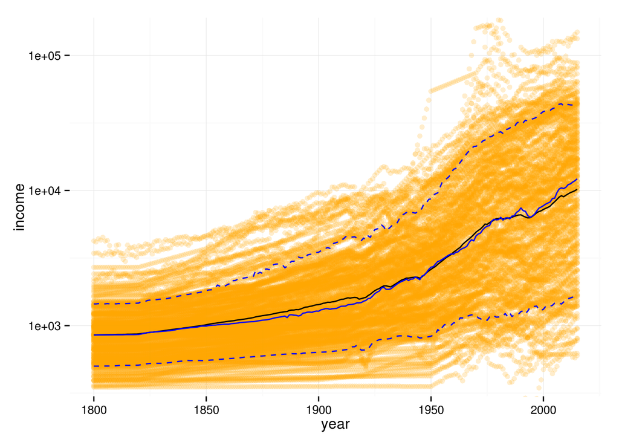

```r
ggplot(aes(x = year, y = income), data = fer_inc) +
  geom_point(alpha = 0.2, color = 'orange') +
  coord_cartesian(ylim=c(300, 190000)) +
  scale_y_log10() +
  geom_line(stat = 'summary', fun.y = mean) +
  geom_line(stat = 'summary', fun.y = median, color = 'blue') +
  geom_line(stat = 'summary', fun.y = quantile, probs = .1, linetype = 2, color = 'blue') +
  geom_line(stat = 'summary', fun.y = quantile, probs = .9, linetype = 2, color = 'blue')
```

```r
fer_inc[!is.na(fer_inc$income) & fer_inc$income < 300,]
```

```
##       country year income fertility
## 26761 Liberia 1992    290      6.34
## 26762 Liberia 1993    197      6.27
## 26763 Liberia 1994    153      6.21
## 26764 Liberia 1995    142      6.16
## 26765 Liberia 1996    151      6.11
## 26766 Liberia 1997    289      6.06
```

### How did income and fertility changed in time?

```r
fer_inc.means <- fer_inc %>%
  group_by(year) %>%
  summarise(mean_income = mean(income, na.rm = TRUE),
            mean_fertility = mean(fertility, na.rm = TRUE),
            n = n()) %>%
  arrange(year)
head(fer_inc.means)
```

```
## Source: local data frame [6 x 4]
##
##    year mean_income mean_fertility     n
##   (dbl)       (dbl)          (dbl) (int)
## 1  1800     948.485       6.084080   258
## 2  1801     948.860       6.081244   258
## 3  1802     951.665       6.084328   258
## 4  1803     951.405       6.083383   258
## 5  1804     952.965       6.083682   258
## 6  1805     953.400       6.083433   258
```

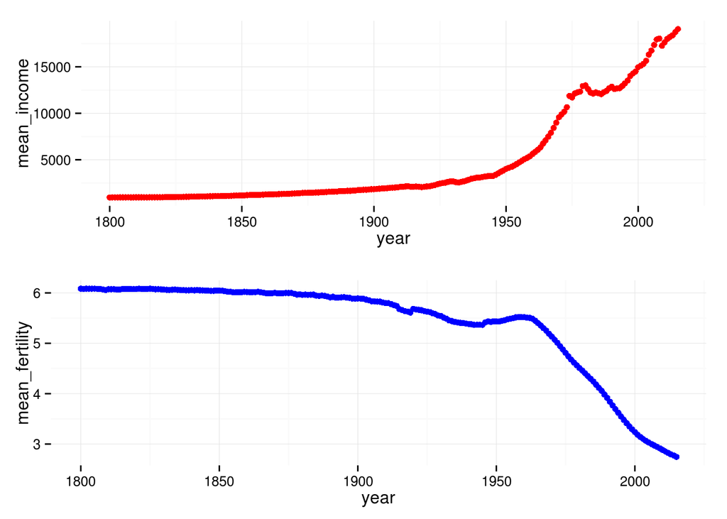

```r
p1 <- ggplot(aes(x = year), data = fer_inc.means) +
  geom_point(aes(y = mean_income), color = 'red')
p2 <- ggplot(aes(x = year), data = fer_inc.means) +
  geom_point(aes(y = mean_fertility), color = 'blue')
library(gridExtra)
grid.arrange(p1, p2, ncol=1)
```

```r
cor.test(fer_inc$income, fer_inc$fertility)
```

```
##
##  Pearson's product-moment correlation
##
## data:  fer_inc$income and fer_inc$fertility
## t = -112.19, df = 40798, p-value < 2.2e-16
## alternative hypothesis: true correlation is not equal to 0
## 95 percent confidence interval:
##  -0.4929551 -0.4781238
## sample estimates:
##        cor
## -0.4855744
```